# Global Health Indicators Analysis: Basic Sanitation Access and Life Expectancy (2020)

Automated R Report

2025-10-21

### Overview

This report analyzes the relationship between basic sanitation access and life expectancy across countries in 2020, using Gapminder-style datasets.

- Indicator 1: Basic sanitation access (% of population)
- Indicator 2: Life expectancy (years)

## Load Data and Peek at Samples

Sample: Basic Sanitation Access

| geo | name | 2018 | 2019 | 2020 |
| --- | --- | --- | --- | --- |
| afg | Afghanistan | 49.23414 | 51.00348 | 52.64900 |
| ago | Angola | 51.12074 | 51.39362 | 51.66033 |
| alb | Albania | 98.97365 | 99.18307 | 99.29879 |
| and | Andorra | 100.00000 | 100.00000 | 100.00000 |
| are | UAE | 99.10102 | 99.09848 | 99.09601 |
| arg | Argentina | NA | NA | NA |

Sample: Life Expectancy

| geo | name | 2018 | 2019 | 2020 |
| --- | --- | --- | --- | --- |
| afg | Afghanistan | 62.73 | 63.33 | 62.34 |
| ago | Angola | 64.63 | 65.08 | 64.88 |
| alb | Albania | 78.44 | 78.50 | 76.23 |
| and | Andorra | 82.14 | 82.19 | 78.25 |
| are | UAE | 73.72 | 73.90 | 73.18 |
| arg | Argentina | 76.48 | 76.58 | 75.20 |

## Subset to 2020 and Combine

- Countries with both indicators in 2020: 181
- Sanitation access range: 9.0–100.0%
- Life expectancy range: 52.0–85.1 years

## World Map Visualizations (2020)

### Basic Sanitation Access (2020)

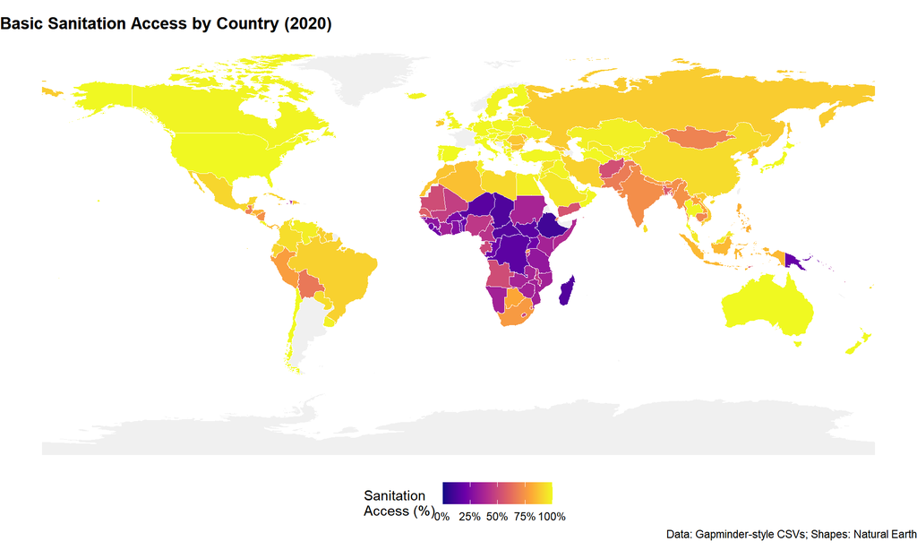

### Life Expectancy (2020)

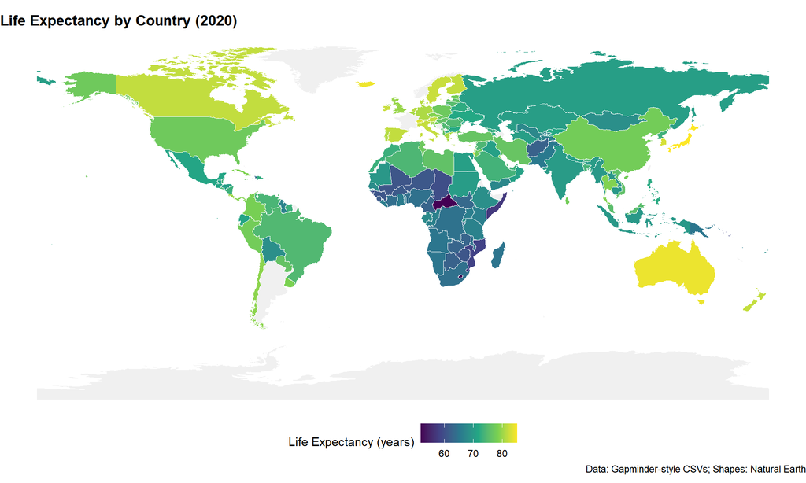

## Relationship Between Indicators (2020)

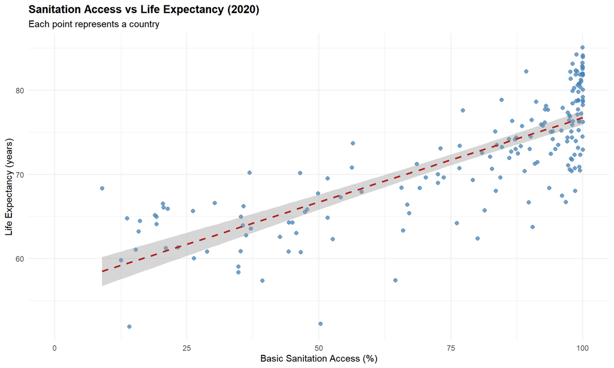

Summary statistics for 2020 across countries with both indicators

| Countries | Mean_Sanitation | Mean_Life_Expectancy | Correlation |
| --- | --- | --- | --- |
| 181 | 77.1 | 72.1 | 0.785 |

## Brief Interpretation

- The correlation between sanitation access and life expectancy in 2020 is 0.785, indicating a positive association.
- Countries with higher access to basic sanitation (often >80%) tend to have life expectancy above ~70 years.
- Countries with low sanitation access (<50%) typically exhibit substantially lower life expectancy.
- This supports the role of water, sanitation, and hygiene (WASH) infrastructure in reducing communicable disease burden and improving population longevity.

## Reflection on AI Tool Interaction

The process of interacting with AI tools revealed distinct aspects of the workflow. What proved straightforward was the initial setup—creating the project structure and preparing datasets. The most challenging component was crafting effective prompts, which required considerable thought and precision to guide the AI appropriately. A surprising element was the AI agent’s capability to transform these prompts into clear, actionable outputs, readily understandable for decision-making purposes. Ultimately, this experience highlighted the critical importance of structured thinking and carefully formulated queries to leverage AI tools effectively for generating meaningful analytical reports.